# Practical Machine Learning, Project Writeup

Sunday, September 21, 2014

### Introduction

This is a Project Writeup for Coiursera “Practical Machine Learning” course. Here we will analyze data from accelerometers on the belt, forearm, arm, and dumbell of 6 participants ( http://groupware.les.inf.puc-rio.br/har). The goal of this project is to predict the manner in which they did the exercise. The follwoing chapters describes the steps we have used to prepare the final prediction model.

### 1. Pre-processing and Cleaning Data

#### 1.1 Loading data

- Here we are loading empty strings as NA to avoid confusion.
- We have already downloaded the training dataset from “https://d396qusza40orc.cloudfront.net/predmachlearn/pml-training.csv” to current working directory of R.

```r
rawData <- read.csv("pml-training.csv", header=TRUE, na.strings=c("NA","NaN", " ", ""))
```

#### 1.2 Do some initial exploration

```r
nrow(rawData)
```

```
## [1] 19622
```

```r
head(rawData,10)
```

[output not shown]

#### 1.3 lets check how many records with complete attributes

```r
nrow(rawData[complete.cases(rawData),])
```

```
## [1] 406
```

- only 406, too less

```r
sum(colSums(is.na(rawData)) > nrow(rawData) * 0.75)
```

```
## [1] 100
```

#### 1.5 Eliminate colums which have too many NAs

```r
cleanData <- rawData[,!colSums(is.na(rawData)) > nrow(rawData) * 0.75]
```

#### 1.6 Timestamps will not be that much usable in general. So, lets try with avoiding them.

- eliminate unnecessary column (username, timestamps etc)

```r
drops <- c("user_name","raw_timestamp_part_1","raw_timestamp_part_2","cvtd_timestamp")
cleanData <- cleanData[,!(names(cleanData) %in% drops)]
```

#### 1.7 Prepare the final data set

- Lets check again all the records with complete records

```r
nrow(cleanData[complete.cases(cleanData),])
```

```
## [1] 19622
```

- Now seems ok to prepare final set

```r
finalData <- cleanData[complete.cases(cleanData),]
```

- make sure we have not eliminated the outcome column and all the records are there

```r
sum(names(finalData)=="classe")
```

```
## [1] 1
```

```r
length(finalData)
```

```
## [1] 56
```

### 2. Dataset Preparation

#### 2.1 Initially keep a sperate set of data for cross validation. We will run pretiction test only one time at the end.

- Load caret package

```r
library(caret)
```

- Seperate a finalTest set. 10% of total dataset.

```r
inTempTrain <- createDataPartition(y=finalData$classe, p=0.10, list=FALSE)
finalTest <- finalData[inTempTrain,]
tempTraining <- finalData[-inTempTrain,]
```

#### 2.2 We will use ‘tempTraining’ data set for the rest of machine learning activities.

#### 2.3 We will use ‘finalTest’ data set for only 1 time at the end of the analysis for out of sample testing.

### 3. Initial Prediction Analysis

#### 3.1 use small amount of data to do initial prediction test

- Prepare a small training data set, it will be very fast to do initial modeling

```r
inTrain <- createDataPartition(y=tempTraining$classe, p=0.05, list=FALSE)
training <- tempTraining[inTrain,]
testing <- tempTraining[-inTrain,]
```

#### 3.2 lets try with simple tree

```r
modelFit <- train(classe ~ .,method="rpart",data=training)
modelFit$finalModel
```

```
## n= 885
##
## node), split, n, loss, yval, (yprob)
##       * denotes terminal node
##
## 1) root 885 633 A (0.28 0.19 0.17 0.16 0.18)
##   2) X< 5570 252   0 A (1 0 0 0 0) *
##   3) X>=5570 633 462 B (0 0.27 0.24 0.23 0.26)
##     6) X< 9370 171   0 B (0 1 0 0 0) *
##     7) X>=9370 462 299 E (0 0 0.33 0.31 0.35) *
```

- Above shows it is only based on a single variable “X”

#### 3.3 Explore the only predictor a bit more

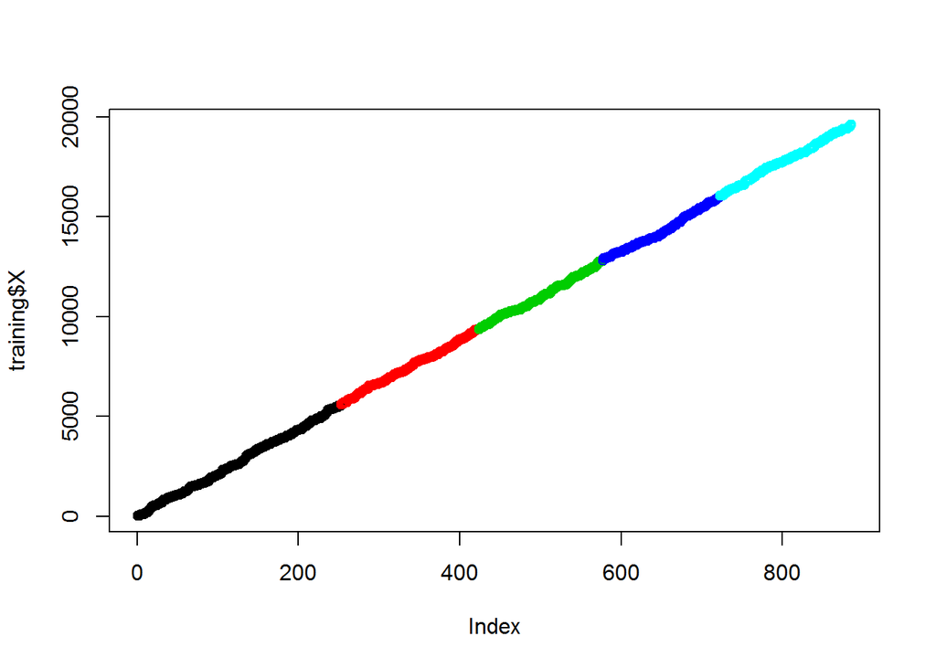

```r
plot(training$X,col=training$classe)
```

- Above shows that “X” is sequentialy increasing variable and values of training$classe are also sorted sequentially, seems no real correlation

#### 3.4 Try tree without “X”

```r
training <- training[,!(names(training) == "X")]
modelFit <- train(classe ~ .,method="rpart",data=training)
modelFit$finalModel
```

```
## n= 885
##
## node), split, n, loss, yval, (yprob)
##       * denotes terminal node
##
##  1) root 885 633 A (0.28 0.19 0.17 0.16 0.18)
##    2) roll_belt< 129.5 812 564 A (0.31 0.21 0.19 0.18 0.12)
##      4) pitch_forearm< -32.9 84   1 A (0.99 0.012 0 0 0) *
##      5) pitch_forearm>=-32.9 728 558 B (0.23 0.23 0.21 0.2 0.13)
##       10) magnet_dumbbell_y< 430 607 447 A (0.26 0.17 0.25 0.19 0.12)
##         20) roll_forearm< 125 363 220 A (0.39 0.19 0.19 0.17 0.063) *
##         21) roll_forearm>=125 244 162 C (0.07 0.14 0.34 0.24 0.21) *
##       11) magnet_dumbbell_y>=430 121  55 B (0.041 0.55 0.033 0.22 0.16) *
##    3) roll_belt>=129.5 73   4 E (0.055 0 0 0 0.95) *
```

- Now seems better, atleast using more variables
- Let’s check prediction rate

```r
confusionMatrix(testing$classe, predict(modelFit, testing))$overall["Accuracy"]
```

```
## Accuracy
##   0.4951
```

- Good but not impressive. Lets try with more data.

```r
inTrain <- createDataPartition(y=tempTraining$classe, p=0.5, list=FALSE)
training <- tempTraining[inTrain,]
testing <- tempTraining[-inTrain,]
training <- training[,!(names(training) == "X")]
modelFit <- train(classe ~ .,method="rpart",data=training)
modelFit$finalModel
```

[output not shown]

```r
confusionMatrix(testing$classe, predict(modelFit, testing))$overall["Accuracy"]
```

```
## Accuracy
##   0.5518
```

- No significant improvement

#### 3.5 So, it seems we need to use more sophisticated models & also need to Exclude “X” from predictors.

### 4. Final Prediction Modeling

#### 4.1 Prepare the dataset.

- Still we will try to use small amount(30%) of data for training to reduce training time and also avoiding overfitting.

```r
drops <- c("user_name", "raw_timestamp_part_1", "raw_timestamp_part_2", "cvtd_timestamp", "X")
tempTraining <- tempTraining[,!(names(tempTraining) %in% drops)]
inTrain <- createDataPartition(y=tempTraining$classe, p=0.30, list=FALSE)
training <- tempTraining[inTrain,]
testing <- tempTraining[-inTrain,]
```

#### 4.2 Lets train a model with boosting.

- We are using smaller number of n.trees to reduce training time.
- If accuracy is acceptable, we will not increase n.tree.

```r
gbmGrid <-  expand.grid(interaction.depth = 5, n.trees = 100, shrinkage = 0.1)
modelFit <- train(classe ~ .,method="gbm",data=training,tuneGrid=gbmGrid)
```

#### 4.3 Check acuracy using

```r
confusionMatrix(testing$classe, predict(modelFit, testing))
```

```
## Confusion Matrix and Statistics
##
##           Reference
## Prediction    A    B    C    D    E
##          A 3510    4    1    0    0
##          B   30 2321   38    1    1
##          C    0   29 2125    1    0
##          D    0    8   21 1992    4
##          E    1   11    7   13 2240
##
## Overall Statistics
##
##                Accuracy : 0.986
##                  95% CI : (0.984, 0.988)
##     No Information Rate : 0.287
##     P-Value [Acc > NIR] : <2e-16
##
##                   Kappa : 0.983
##  Mcnemar's Test P-Value : NA
##
## Statistics by Class:
##
##                      Class: A Class: B Class: C Class: D Class: E
## Sensitivity             0.991    0.978    0.969    0.993    0.998
## Specificity             0.999    0.993    0.997    0.997    0.997
## Pos Pred Value          0.999    0.971    0.986    0.984    0.986
## Neg Pred Value          0.996    0.995    0.993    0.999    1.000
## Prevalence              0.287    0.192    0.177    0.162    0.182
## Detection Rate          0.284    0.188    0.172    0.161    0.181
## Detection Prevalence    0.284    0.193    0.174    0.164    0.184
## Balanced Accuracy       0.995    0.986    0.983    0.995    0.997
```

#### 4.4 Accuracy seems encouraging. So, we can go forward for validation.

### 5. Cross validation

#### 5.1 For Cross validation we have prepared 3 list as below:

- A fully seperated final test set. We will run prediction testing only once as if out of sample testing.
- Rest of the data will be used for training and in sample testing
- A test & a training set from the rest of the sample
- We have used smaller amount of data for training and larget for testing. It will make help us reduce the change of overfitting.

#### 5.2 In sample accuracy

- From the point **4.3** it accuracy is very good for in sample testing. Error rate is very low.
- **Our training set was smaller and testing set was larger and still in sample accuracy is very good. So, we think that out of sample error will also be low.**

#### 5.2 Out of Sample accuracy

- Lets try with out of sample:

```r
confusionMatrix(finalTest$classe, predict(modelFit, finalTest))
```

```
## Confusion Matrix and Statistics
##
##           Reference
## Prediction   A   B   C   D   E
##          A 558   0   0   0   0
##          B  10 367   3   0   0
##          C   0   2 341   0   0
##          D   0   1   9 310   2
##          E   0   2   1   1 357
##
## Overall Statistics
##
##                Accuracy : 0.984
##                  95% CI : (0.978, 0.989)
##     No Information Rate : 0.289
##     P-Value [Acc > NIR] : <2e-16
##
##                   Kappa : 0.98
##  Mcnemar's Test P-Value : NA
##
## Statistics by Class:
##
##                      Class: A Class: B Class: C Class: D Class: E
## Sensitivity             0.982    0.987    0.963    0.997    0.994
## Specificity             1.000    0.992    0.999    0.993    0.998
## Pos Pred Value          1.000    0.966    0.994    0.963    0.989
## Neg Pred Value          0.993    0.997    0.992    0.999    0.999
## Prevalence              0.289    0.189    0.180    0.158    0.183
## Detection Rate          0.284    0.187    0.174    0.158    0.182
## Detection Prevalence    0.284    0.193    0.175    0.164    0.184
## Balanced Accuracy       0.991    0.989    0.981    0.995    0.996
```

- Seems very good out os sample accuracy as expected in point **5.2**.

#### 5.3 Finalize Model Selection

- **We can say, the difference between insample and out of sample error not that significant. Still very good accuracy.**
- **So, we can chose this model(step 4.2) as final, as it fast and and accurate**.

### Conclusion

We have relied directly on the acapbility of tools(caret) we used to identify important predictors. So, there was no effort to select predictor using PCA or other options. Although we are getting very good prediction accuracy it may be not the same is all cases. On the other hand, we have used boosting which is not easy to interpret. We can improve interpretation if we could use other simpler method.